# Multivariate Analysis of Variance

## Multivariate analysis of variance

- Standard ANOVA has just one response variable.
- What if you have more than one response?
- Try an ANOVA on each response separately.
- But might miss some kinds of interesting dependence between the responses that distinguish the groups.

## Packages

```r
library(car) # may need to install first
library(tidyverse)
library(MVTests) # also may need to install
```

## Small example

- Measure yield and seed weight of plants grown under 2 conditions: low and high amounts of fertilizer.
- Data (fertilizer, yield, seed weight):

```r
url <- "http://ritsokiguess.site/datafiles/manova1.txt"
hilo <- read_delim(url, " ")
```

- 2 responses, yield and seed weight.

## The data

```r
hilo
```

| fertilizer | yield | weight |
| --- | --- | --- |
| low | 34 | 10 |
| low | 29 | 14 |
| low | 35 | 11 |
| low | 32 | 13 |
| high | 33 | 14 |
| high | 38 | 12 |
| high | 34 | 13 |
| high | 35 | 14 |

## Boxplot for yield for each fertilizer group

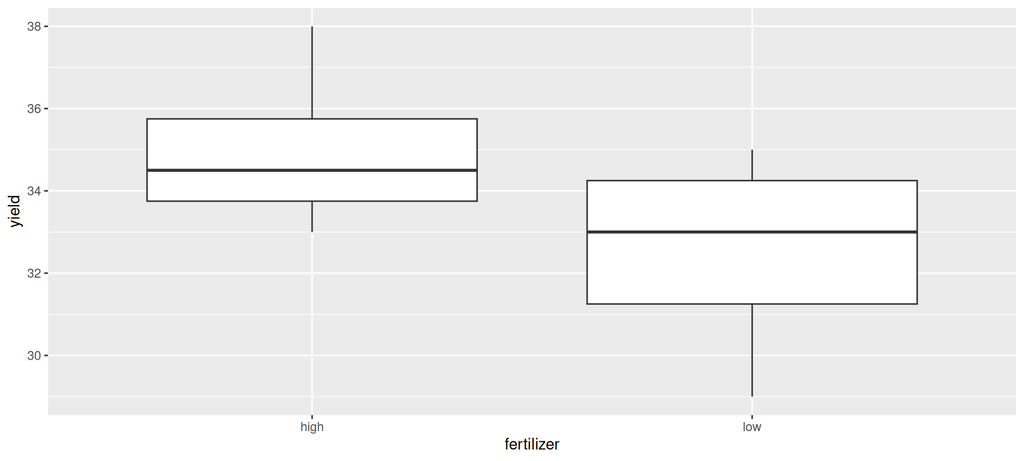

```r
ggplot(hilo, aes(x = fertilizer, y = yield)) + geom_boxplot()
```

Yields overlap for fertilizer groups.

## Boxplot for weight for each fertilizer group

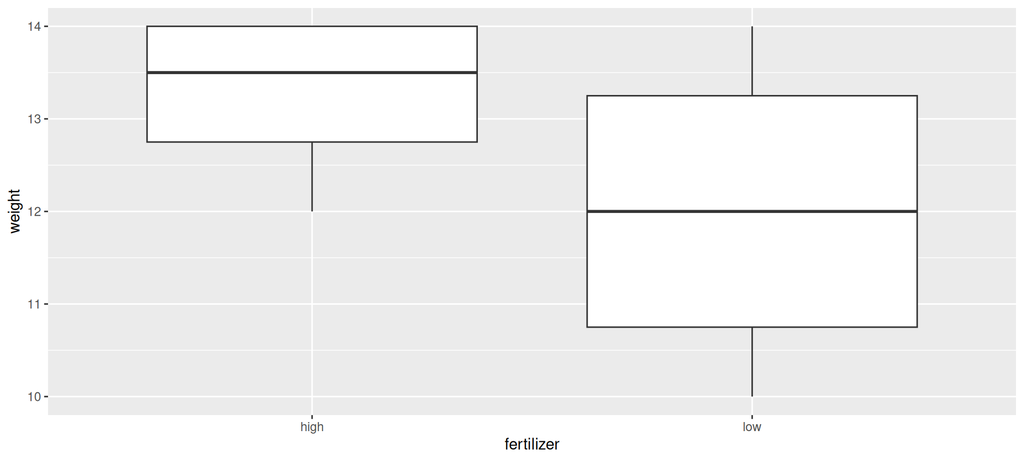

```r
ggplot(hilo, aes(x = fertilizer, y = weight)) + geom_boxplot()
```

Weights overlap for fertilizer groups.

## ANOVAs for yield and weight

```r
hilo.y <- aov(yield ~ fertilizer, data = hilo)
summary(hilo.y)
```

```
            Df Sum Sq Mean Sq F value Pr(>F)
fertilizer   1   12.5  12.500   2.143  0.194
Residuals    6   35.0   5.833
```

```r
hilo.w <- aov(weight ~ fertilizer, data = hilo)
summary(hilo.w)
```

```
            Df Sum Sq Mean Sq F value Pr(>F)
fertilizer   1  3.125   3.125   1.471  0.271
Residuals    6 12.750   2.125
```

Neither response depends significantly on fertilizer. But…

## Plotting both responses at once

- Have two response variables (not more), so can plot the response variables against *each other*, labelling points by which fertilizer group they’re from.
- First, create data frame with points $(31,14)$ and $(38,10)$ (why? Later):

```r
d <- tribble(
  ~line_x, ~line_y,
  31, 14,
  38, 10
)
```

- Then plot data as points, and add line through points in `d`:

```r
ggplot(hilo, aes(x = yield, y = weight,
                      colour = fertilizer)) + geom_point() +
  geom_line(data = d,
            aes(x = line_x, y = line_y, colour = NULL)) -> g
```

## The plot

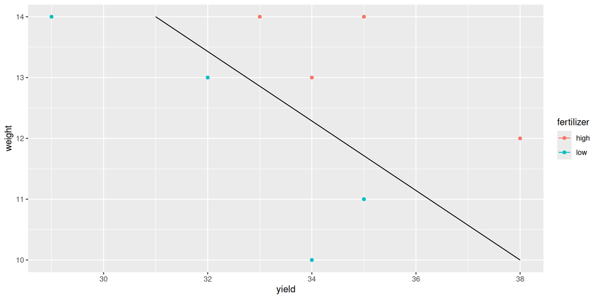

## Comments

- Graph construction:
  - Joining points in `d` by line.
  - `geom_line` inherits `colour` from `aes` in `ggplot`.
  - Data frame `d` has no `fertilizer` (previous `colour`), so have to unset.
- Results:
  - High-fertilizer plants have both yield and weight high.
  - True even though no sig difference in yield or weight individually.
  - Drew line separating highs from lows on plot.

## MANOVA finds multivariate differences

- Is difference found by diagonal line significant? MANOVA finds out.

```r
response <- with(hilo, cbind(yield, weight))
hilo.1 <- manova(response ~ fertilizer, data = hilo)
summary(hilo.1)
```

```
           Df  Pillai approx F num Df den Df  Pr(>F)
fertilizer  1 0.80154   10.097      2      5 0.01755 *
Residuals   6
---
Signif. codes:
0 '***' 0.001 '**' 0.01 '*' 0.05 '.' 0.1 ' ' 1
```

- Yes! Difference between groups is *diagonally*, not just up/down (weight) or left-right (yield). The *yield-weight combination* matters.

## Strategy

- Create new response variable by gluing together columns of responses, using `cbind`.
- Use `manova` with new response, looks like `lm` otherwise.
- With more than 2 responses, cannot draw graph. What then?
- If MANOVA test significant, cannot use Tukey. What then?
- Use *discriminant analysis* (of which more later).

## Another way to do MANOVA

using `Manova` from package `car`:

```r
hilo.2.lm <- lm(response ~ fertilizer, data = hilo)
hilo.2 <- Manova(hilo.2.lm)
summary(hilo.2)
```

```
Type II MANOVA Tests:

Sum of squares and products for error:
       yield weight
yield     35 -18.00
weight   -18  12.75

------------------------------------------

Term: fertilizer

Sum of squares and products for the hypothesis:
       yield weight
yield  12.50  6.250
weight  6.25  3.125

Multivariate Tests: fertilizer
                 Df test stat approx F num Df den Df   Pr(>F)
Pillai            1  0.801542 10.09714      2      5 0.017546 *
Wilks             1  0.198458 10.09714      2      5 0.017546 *
Hotelling-Lawley  1  4.038855 10.09714      2      5 0.017546 *
Roy               1  4.038855 10.09714      2      5 0.017546 *
---
Signif. codes:  0 '***' 0.001 '**' 0.01 '*' 0.05 '.' 0.1 ' ' 1
```

## Comments

- Same result as small-m `manova`.
- `Manova` will also do *repeated measures*, coming up later.

## Assumptions

- normality of each response variable within each treatment group
  - this is actually *multivariate* normality, with correlations
- equal spreads: each response variable has same variances and correlations (with other response variables) within each treatment group. Here:
  - yield has same spread for low and high fertilizer
  - weight has same spread for low and high fertilizer
  - correlation between yield and weight is same for low and high fertilizer
- test equal spread using Box’s $M$ test
  - a certain amount of unequalness is OK, so only a concern if P-value from $M$-test is very small (eg. less than 0.001).

## Assumptions for yield-weight data

For normal quantile plots, need “extra-long” with all the data values in one column:

```r
hilo %>%
  pivot_longer(-fertilizer, names_to = "xname",
               values_to = "xvalue") %>%
  ggplot(aes(sample = xvalue)) + stat_qq() +
    stat_qq_line() +
    facet_grid(xname ~ fertilizer, scales = "free") -> g
```

There are only four observations per response variable - treatment group combination, so graphs are not very informative (over):

## The plots

```r
g
```

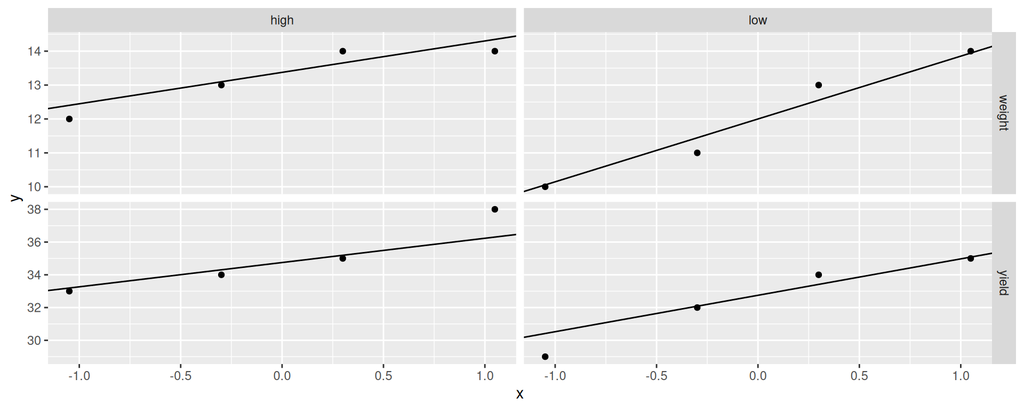

## Box M test

- Make sure package `MVTests` loaded first.
- inputs:
  - the response matrix (or, equivalently, the response-variable columns from your dataframe)
  - the column with the grouping variable in it (most easily gotten with `$`).

```r
library(MVTests)
# hilo %>% select(yield, weight) -> numeric_values
summary(BoxM(response, hilo$fertilizer))
```

```
       Box's M Test

Chi-Squared Value = 1.002964 , df = 3  and p-value: 0.801
```

- No problem at all with unequal spreads.

## Another example: peanuts

- Three different varieties of peanuts (mysteriously, 5, 6 and 8) planted in two different locations.
- Three response variables: `y`, `smk` and `w`.

```r
u <- "http://ritsokiguess.site/datafiles/peanuts.txt"
peanuts.orig <- read_delim(u, " ")
```

## The data

```r
peanuts.orig
```

| obs | location | variety | y | smk | w |
| --- | --- | --- | --- | --- | --- |
| 1 | 1 | 5 | 195.3 | 153.1 | 51.4 |
| 2 | 1 | 5 | 194.3 | 167.7 | 53.7 |
| 3 | 2 | 5 | 189.7 | 139.5 | 55.5 |
| 4 | 2 | 5 | 180.4 | 121.1 | 44.4 |
| 5 | 1 | 6 | 203.0 | 156.8 | 49.8 |
| 6 | 1 | 6 | 195.9 | 166.0 | 45.8 |
| 7 | 2 | 6 | 202.7 | 166.1 | 60.4 |
| 8 | 2 | 6 | 197.6 | 161.8 | 54.1 |
| 9 | 1 | 8 | 193.5 | 164.5 | 57.8 |
| 10 | 1 | 8 | 187.0 | 165.1 | 58.6 |

[output cut: 2 more lines]

## Setup for analysis

```r
peanuts.orig %>%
  mutate(
    location = factor(location),
    variety = factor(variety)
  ) -> peanuts
peanuts
```

| obs | location | variety | y | smk | w |
| --- | --- | --- | --- | --- | --- |
| 1 | 1 | 5 | 195.3 | 153.1 | 51.4 |
| 2 | 1 | 5 | 194.3 | 167.7 | 53.7 |
| 3 | 2 | 5 | 189.7 | 139.5 | 55.5 |
| 4 | 2 | 5 | 180.4 | 121.1 | 44.4 |
| 5 | 1 | 6 | 203.0 | 156.8 | 49.8 |
| 6 | 1 | 6 | 195.9 | 166.0 | 45.8 |
| 7 | 2 | 6 | 202.7 | 166.1 | 60.4 |
| 8 | 2 | 6 | 197.6 | 161.8 | 54.1 |
| 9 | 1 | 8 | 193.5 | 164.5 | 57.8 |
| 10 | 1 | 8 | 187.0 | 165.1 | 58.6 |

[output cut: 2 more lines]

```r
response <- with(peanuts, cbind(y, smk, w))
head(response)
```

```
         y   smk    w
[1,] 195.3 153.1 51.4
[2,] 194.3 167.7 53.7
[3,] 189.7 139.5 55.5
[4,] 180.4 121.1 44.4
[5,] 203.0 156.8 49.8
[6,] 195.9 166.0 45.8
```

## Analysis (using `manova`)

```r
peanuts.1 <- manova(response ~ location * variety, data = peanuts)
summary(peanuts.1)
```

```
                 Df  Pillai approx F num Df den Df   Pr(>F)
location          1 0.89348  11.1843      3      4 0.020502
variety           2 1.70911   9.7924      6     10 0.001056
location:variety  2 1.29086   3.0339      6     10 0.058708
Residuals         6

location         *
variety          **
location:variety .
Residuals
---
Signif. codes:
0 '***' 0.001 '**' 0.01 '*' 0.05 '.' 0.1 ' ' 1
```

## Comments

- Interaction not quite significant, but main effects are.
- Combined response variable `(y,smk,w)` definitely depends on location and on variety
- Weak dependence of `(y,smk,w)` on the location-variety *combination.*
- Understanding that dependence beyond our scope right now.

## Comments

- this time there are only six observations per location and four per variety, so normality is still difficult to be confident about
- `y` at location 1 seems to be the worst for normality (long tails / outliers), and maybe `y` at location 2 is skewed left, but the others are not bad
- there is some evidence of unequal spread (slopes of lines), but is it bad enough to worry about? (Box M-test, over).

## Assessing normality

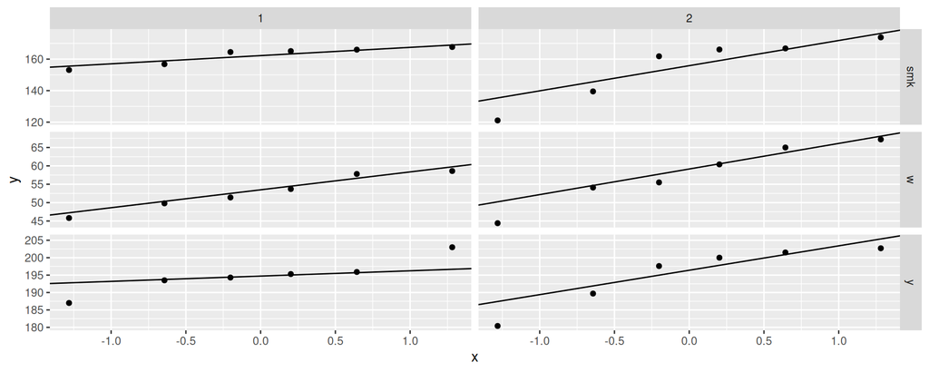

```r
peanuts %>% pivot_longer(y:w, names_to = "yname",
                         values_to = "y") %>%
  ggplot(aes(sample = y)) + stat_qq() + stat_qq_line() +
  facet_grid(yname ~ location, scales = "free_y")
```

## Box’s M tests

- One for location, one for variety:

```r
summary(BoxM(response, peanuts$location))
```

```
       Box's M Test

Chi-Squared Value = 12.47797 , df = 6  and p-value: 0.0521
```

```r
summary(BoxM(response, peanuts$variety))
```

```
       Box's M Test

Chi-Squared Value = 10.56304 , df = 12  and p-value: 0.567
```

- Neither of these P-values is low enough to worry about. (Remember, the P-value here has to be *really* small to indicate a problem.)
- Box’s M test does not work well (and can fail to work at all) if the sample sizes are too small.

## Addendum: Box’s M for interaction

- Create a combo column that is the combination of location and variety:

```r
peanuts %>% mutate(combo =
                     str_c(location, "-", variety)) -> d
d
```

| obs | location | variety | y | smk | w | combo |
| --- | --- | --- | --- | --- | --- | --- |
| 1 | 1 | 5 | 195.3 | 153.1 | 51.4 | 1-5 |
| 2 | 1 | 5 | 194.3 | 167.7 | 53.7 | 1-5 |
| 3 | 2 | 5 | 189.7 | 139.5 | 55.5 | 2-5 |
| 4 | 2 | 5 | 180.4 | 121.1 | 44.4 | 2-5 |
| 5 | 1 | 6 | 203.0 | 156.8 | 49.8 | 1-6 |
| 6 | 1 | 6 | 195.9 | 166.0 | 45.8 | 1-6 |
| 7 | 2 | 6 | 202.7 | 166.1 | 60.4 | 2-6 |
| 8 | 2 | 6 | 197.6 | 161.8 | 54.1 | 2-6 |
| 9 | 1 | 8 | 193.5 | 164.5 | 57.8 | 1-8 |
| 10 | 1 | 8 | 187.0 | 165.1 | 58.6 | 1-8 |

[output cut: 2 more lines]

## Then run Box’s M test as usual:

```r
summary(BoxM(response, d$combo))
```

```
       Box's M Test

Chi-Squared Value = -Inf , df = 30  and p-value: 1
```

except that the result makes no sense. This is because there are only two observations per location-variety combination, which is not enough to estimate anything, and so the test no longer works.